# all_years

Nick_Fox

February 16, 2016

```
## Dev mode: ON
```

# Federal Laboratory Funding in the 21st Century - A 15 Year Review

Authors: Nicholas Fox (Rutgers University) & Mariana Martins (Columbia University)

## Introduction

- Over the last century, research funding from the National Institutes of Health (NIH) have supported hundreds of thousands of independant scientists at more than 2,000 universities accross the country (CITATION - NIH website). Nearly all of the NIH’s funding is provided annually in the Departments of Labor, Health and Human Services, Education, and Related Agencies appropriations act. This act is preceeded by the annual budget presented by the President and any Congressional budget resolutions. Typically, the federal budget needs to be passed by October 1st. If this does not happen, the government can pass short-term “continuing resolutions” (CR) to continue funding to government agencies.

## Since the year 2000, the federal budget has experienced surplus, deficit, and a historic recession. Political battles in Congress have also caused budget deadlines to be missed, resulting in strings of CRs keeping federal agencies running. Additionally, the budget sequestration of 2013 further hamstrung the budget of federal agencies due to the lack of the passing of a proper federal budget.

Things that have happened: Web bubble collapse in 2000 War on Terror: 2001-2014 Deficit Reduction Act of 2005 (February 2006) Great Recession - 2008-2014 Economic Stimulus Act of 2008 (February 2008) Debt Ceiling Crisis of 2011 (July 2011) Budget Control Act of 2011 (August 2011) Debt Ceiling Crisis of 2013 (Janurary 2013) Budget Sequestration of 2013 (March 2013) Government shutdown (October 1st - 16th, 2013)

* The most common (and historically the oldest) source of public funding for independent investigators is the R01 (or R01 equivelent) award. These awards allows an investigator to define the scientific objective of a project and provide funds for the specified project. Projects are awarded to by the NIH to support specific areas of health-related research within a scope defined by the NIH and informed by the President and their scientific advisors.

* In 1998, Congress under the Clinton administration approved a plan to double the NIH buget over 5 years. In 2003, the NIH budget was twice what it was! Since then, this surge in funding was not supported. ((CITATIONS ON DOUBLING ERA))

* So far, it is unknown how these events have affected the NIH’s ability to fund independent research laboratories. This paper describes how R01 equivelent funding has changed over time since the beginning of the 21st century.

Starting in 2007, R01-equivelent awards could have more than one primary investigator. To account for this, the total cost dispersed per application was divided by the number of primary investigators and this number was associated with each individual investigator. This operates on the assumption that award funds are being dispersed evenly to each investigator, but we realize in practice this may not be the case.

Per year, the number of grants per investigator was calculated. This was a count of how many unique Application IDs were associated with each investigator ID. The sum cost was calculated as the sum of the total cost associated with that investigator for each fiscal year.

Year 2000 adjusted dollars were calculated using the Consumer Price Index from the Bureau of Labor Statistics (CITATION - BLS link). An adjustment factor was calculated and applied to the total cost amounts for each year after year 2000.

## Results ### Gini coefficient for inequality The Gini coefficient has been used in previous literature to characterize inieuality in income distributions (CITATION). The coefficient ranges from 0, where income is perfectly distributed among all group members, to 1, where income is perfectly concentrated with one group member. A larger coefficient signifies a greater income disparity. We used the Gini coefficient to describe R01-equivelent award disparity for each fiscal year, and it can be seen in Figure 1.

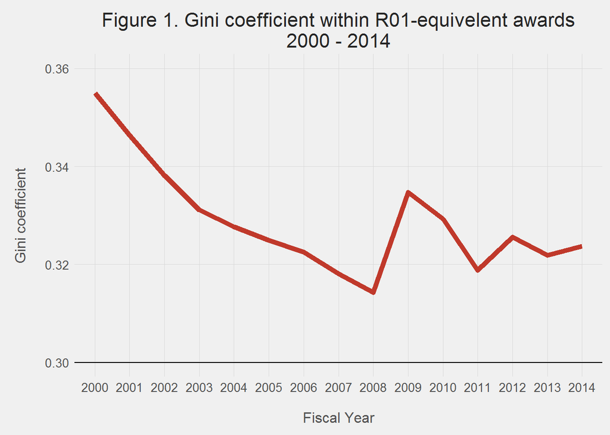

As seen above, the Gini coefficient steadily falls from year 2000 until year 2008, then increases in year 2009. Following this increase, the coefficient again falls, though by year 2014 it is still higher than it’s lowest point.

### Total NIH funds dispersed through R01-equivelent awards Figure 2 below shows the total dollars dispersed by the NIH to R01-equvelent award recepients. The red line shows the dollars reported, and the blue line shows the dollar amount in an inflation-adjusted year 2000 constant dollars.

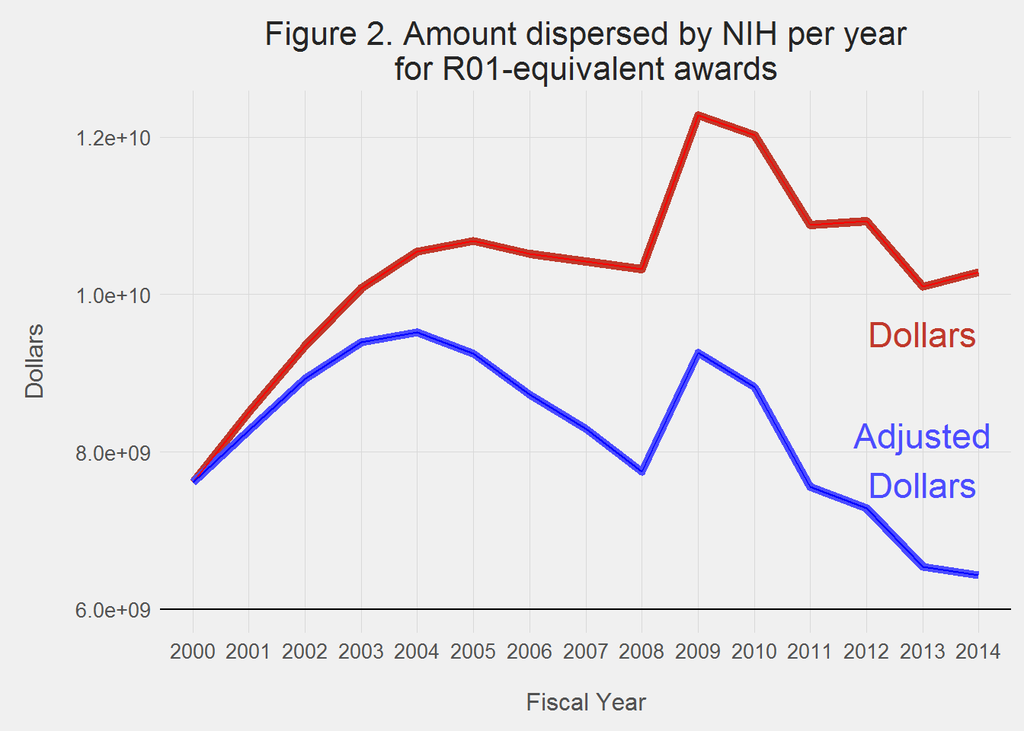

As seen in the figure, in dollars, NIH funds awarded through R01-equvelent awards first peaked and then plateaued from years 2005-2008, then spiked in 2009. In year 2000 constant dollars, this peak occured in 2004, before funds decreased to 2008. In 2009, funds dispersed through these awards spiked, and was also high in 2010. From 2011 on, the amount of dollars dispersed through these awards fell.

### Number of investigators simultaniously supported by one or more than one R01 equivelent grants

Each year, a certain number of unique PIs are funded through R01-equivelent support mechanisms. In Figure 3 below, those PIs are differentiated by the number of awards they receive funds from annually.

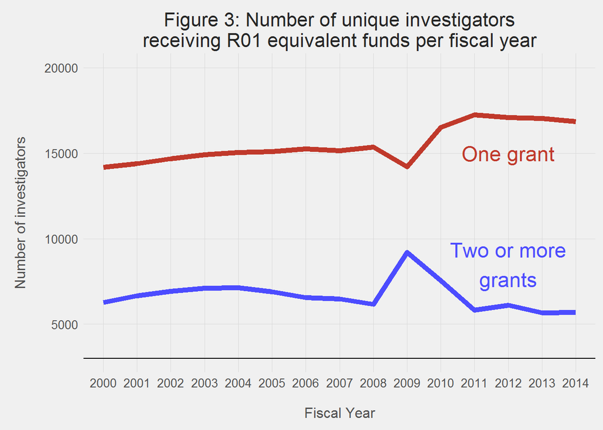

The number of investigators receiving funding from one R01-equivelent grant as increased from FY2000 to FY2014 (from 14,183 to 16,851). This trend changed in 2009, where there was a sharp decrease in the number of investigators being funded by a single R01-equivelent grant. In 2009, only 14,207 investigators were being funded by one R01 award, a decrease of 1,139 from the previous year.

There has been a slight decrease in the number of investigators receiving funding from two or more R01 grants between FY2000 and FY2014 (6,278 to 5,698). In 2009, there was a spike in the number of PIs receiving funding from more than one R01 (9,194).

### Number of investigators simultaniously supported by one or more than one R01 equivelent grants - broken down by ARRA status In 2009, the federal government passed a stimulus package called “The American Recovery and Reinvestment Act” (ARRA). ARRA provided over 10 billion dollars of funding to the NIH, some of which was awarded as R01-equivelent grants in FY2009 and FY2010. The distribution of those ARRA-funded R01-equivelent grants can be seen in Figure 4 below.

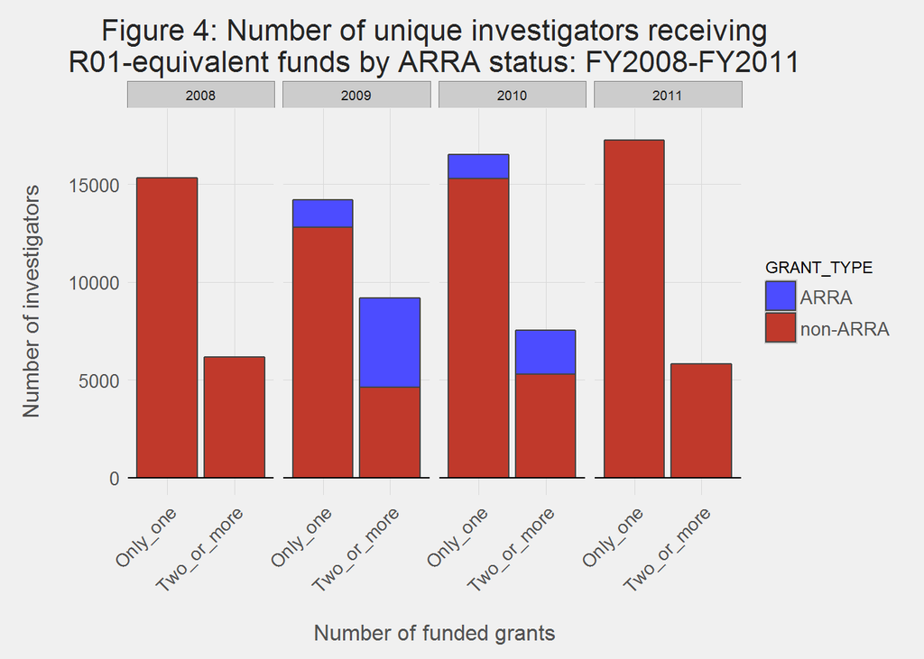

In FY2009, when ARRA-funded grants were first awarded, 77.14% were awarded to PIs who were already being funded by at least 1 R01-equivelent grant. The remaining 22.86% were awarded to investigators as their sole grant. During this time, non-ARRA funded grants decreased for both groups from the previous year. In sum, the distribution of ARRA-funded grants and the decrease of non-ARRA funded grants results in the FY2009 spikes seen in Figure 3.

The relationship is similar in FY2010. In this year, 64.98% of ARRA-funded grants were awarded to PIs who were already being funded by at least 1 R01-equivelent grant. The remaining 35.02% were awarded to investigators as their sole grant.

—Whats Next— Stratify funding by NIH Center. Make proportional bar graphs (every bar = 100%) with stratification within. Do we see a change between 2008 and 2011? Do some centers receive more ARRA funding?

## Discussion

The figures below are orphan figures…

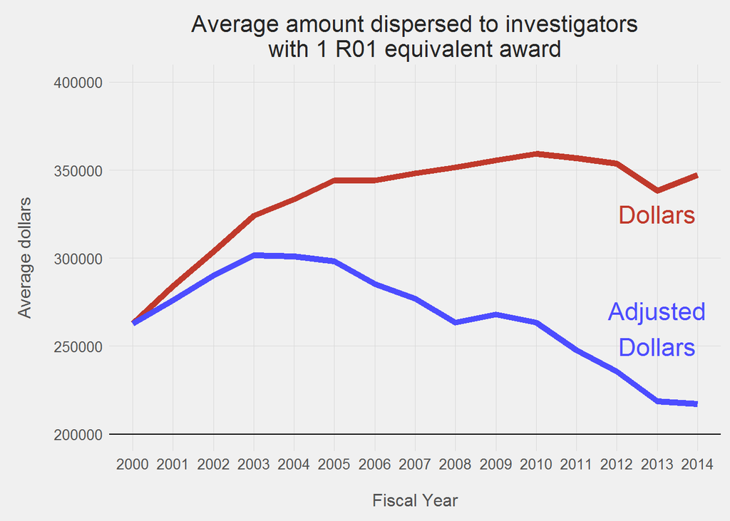

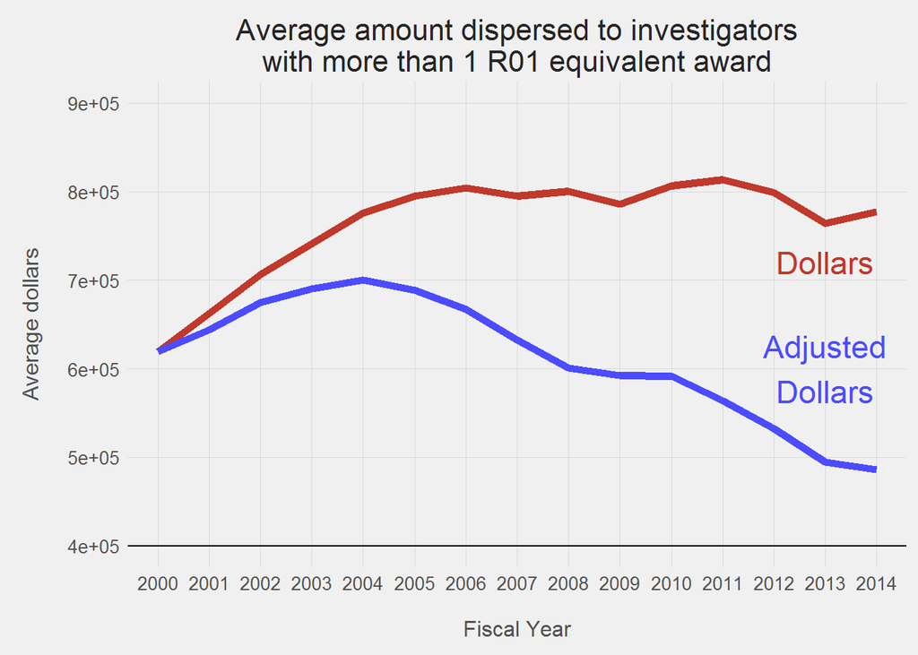

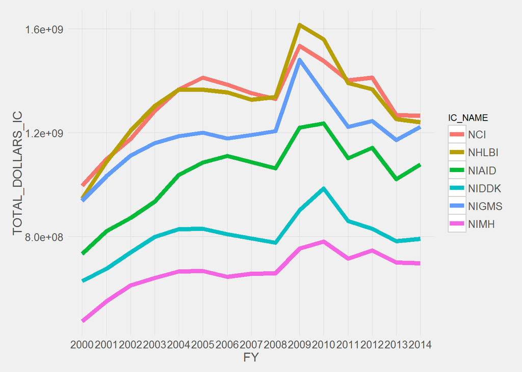

——————-